# Simulating Measurement Invariance Tests

John Flournoy

2018-04-26

# Introduction

# The model

Each iteration evaluates the fit to the below model, either with loadings, intercepts, and residual variances constrained to be the same across 4 groups, or unconstrained. Strict longitudinal invariance is assumed in all models. Conditions vary the number of items per factor (the 4 item case is pictured below), and the strength of loadings. Each iteration draws the loadings randomly from a uniform distribution in a certain range.

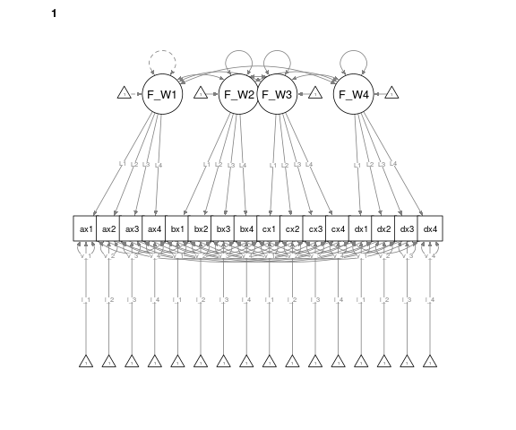

# Variations across items and loadings

Values in the region above the shaded regions would lead us to conclude that measurement is invariant across group. Values below the shaded regions would lead us to reject the hypothesis of invariance.

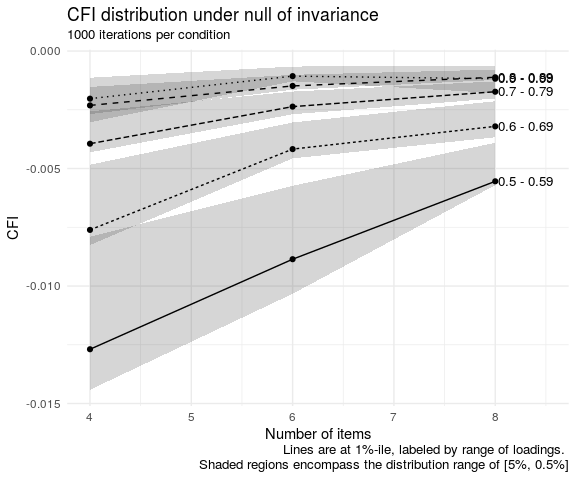

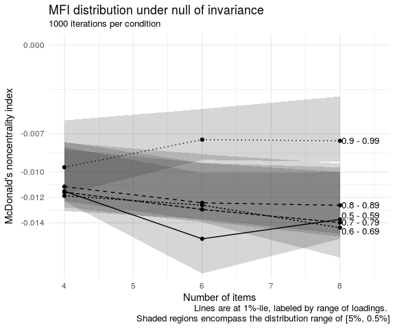

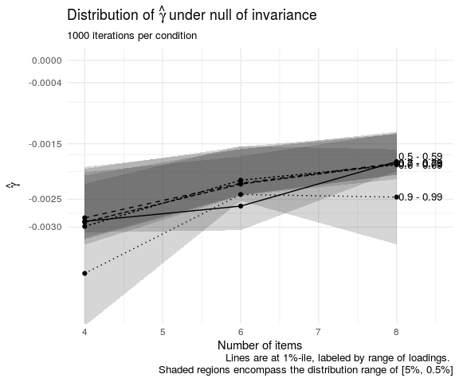

# Result tables

Quantiles over all iterations

|  | mfi | cfi | rmsea | gammaHat | adjGammaHat |
| --- | --- | --- | --- | --- | --- |
| 0.0625% | -0.0187088 | -0.0128725 | -0.0095414 | -0.0045248 | -0.0039535 |
| 0.5% | -0.0140695 | -0.0078816 | -0.0074351 | -0.0030029 | -0.0028649 |
| 1% | -0.0123715 | -0.0064092 | -0.0068067 | -0.0025647 | -0.0024016 |
| 5% | -0.0083957 | -0.0028587 | -0.0041499 | -0.0016768 | -0.0013096 |
| 50% | -0.0002159 | -0.0000004 | -0.0007547 | -0.0000474 | 0.0008409 |
| 95% | 0.0069054 | 0.0023816 | 0.0017029 | 0.0012669 | 0.0112976 |
| 99% | 0.0097943 | 0.0047145 | 0.0047419 | 0.0017640 | 0.0252159 |

Loadings: 0.5 - 0.59; N items: 4

|  | mfi | cfi | rmsea | gammaHat | adjGammaHat |
| --- | --- | --- | --- | --- | --- |
| 1% | -0.0115 | -0.0127 | -0.0081 | -0.0029 | -0.0034 |
| 5% | -0.0080 | -0.0079 | -0.0045 | -0.0020 | -0.0023 |
| 50% | 0.0000 | 0.0000 | 0.0000 | 0.0000 | 0.0002 |
| 95% | 0.0061 | 0.0064 | 0.0044 | 0.0015 | 0.0022 |
| 99% | 0.0081 | 0.0090 | 0.0085 | 0.0020 | 0.0029 |

Loadings: 0.6 - 0.69; N items: 4

|  | mfi | cfi | rmsea | gammaHat | adjGammaHat |
| --- | --- | --- | --- | --- | --- |
| 1% | -0.0119 | -0.0076 | -0.0083 | -0.0030 | -0.0033 |
| 5% | -0.0082 | -0.0048 | -0.0047 | -0.0021 | -0.0022 |
| 50% | -0.0002 | 0.0000 | -0.0002 | -0.0001 | 0.0003 |
| 95% | 0.0060 | 0.0034 | 0.0042 | 0.0015 | 0.0023 |
| 99% | 0.0079 | 0.0049 | 0.0093 | 0.0020 | 0.0029 |

Loadings: 0.7 - 0.79; N items: 4

|  | mfi | cfi | rmsea | gammaHat | adjGammaHat |
| --- | --- | --- | --- | --- | --- |
| 1% | -0.0116 | -0.0039 | -0.0074 | -0.0029 | -0.0028 |
| 5% | -0.0076 | -0.0026 | -0.0042 | -0.0019 | -0.0020 |
| 50% | 0.0001 | 0.0000 | -0.0007 | 0.0000 | 0.0006 |
| 95% | 0.0063 | 0.0022 | 0.0035 | 0.0016 | 0.0027 |
| 99% | 0.0079 | 0.0028 | 0.0083 | 0.0020 | 0.0037 |

Loadings: 0.8 - 0.89; N items: 4

|  | mfi | cfi | rmsea | gammaHat | adjGammaHat |
| --- | --- | --- | --- | --- | --- |
| 1% | -0.0112 | -0.0023 | -0.0048 | -0.0028 | -0.0025 |
| 5% | -0.0077 | -0.0015 | -0.0033 | -0.0020 | -0.0013 |
| 50% | -0.0002 | 0.0000 | -0.0014 | 0.0000 | 0.0015 |
| 95% | 0.0054 | 0.0011 | 0.0017 | 0.0014 | 0.0042 |
| 99% | 0.0072 | 0.0014 | 0.0049 | 0.0019 | 0.0051 |

Loadings: 0.9 - 0.99; N items: 4

|  | mfi | cfi | rmsea | gammaHat | adjGammaHat |
| --- | --- | --- | --- | --- | --- |
| 1% | -0.0096 | -0.0020 | -0.0079 | -0.0038 | -0.0014 |
| 5% | -0.0059 | -0.0011 | -0.0072 | -0.0022 | 0.0010 |
| 50% | -0.0007 | -0.0001 | -0.0042 | -0.0003 | 0.0124 |
| 95% | 0.0035 | 0.0005 | -0.0009 | 0.0011 | 0.0308 |
| 99% | 0.0055 | 0.0008 | 0.0013 | 0.0017 | 0.0341 |

Loadings: 0.5 - 0.59; N items: 6

|  | mfi | cfi | rmsea | gammaHat | adjGammaHat |
| --- | --- | --- | --- | --- | --- |
| 1% | -0.0153 | -0.0089 | -0.0044 | -0.0026 | -0.0027 |
| 5% | -0.0101 | -0.0057 | -0.0026 | -0.0017 | -0.0016 |
| 50% | 0.0001 | 0.0000 | -0.0002 | 0.0000 | 0.0003 |
| 95% | 0.0072 | 0.0042 | 0.0025 | 0.0012 | 0.0017 |
| 99% | 0.0096 | 0.0057 | 0.0052 | 0.0016 | 0.0023 |

Loadings: 0.6 - 0.69; N items: 6

|  | mfi | cfi | rmsea | gammaHat | adjGammaHat |
| --- | --- | --- | --- | --- | --- |
| 1% | -0.0126 | -0.0042 | -0.0048 | -0.0022 | -0.0022 |
| 5% | -0.0093 | -0.0030 | -0.0028 | -0.0016 | -0.0015 |
| 50% | 0.0000 | 0.0000 | -0.0003 | 0.0000 | 0.0003 |
| 95% | 0.0082 | 0.0026 | 0.0024 | 0.0014 | 0.0019 |
| 99% | 0.0106 | 0.0035 | 0.0046 | 0.0018 | 0.0024 |

Loadings: 0.7 - 0.79; N items: 6

|  | mfi | cfi | rmsea | gammaHat | adjGammaHat |
| --- | --- | --- | --- | --- | --- |
| 1% | -0.0129 | -0.0024 | -0.0032 | -0.0022 | -0.0019 |
| 5% | -0.0093 | -0.0017 | -0.0023 | -0.0016 | -0.0013 |
| 50% | 0.0003 | 0.0000 | -0.0005 | 0.0000 | 0.0005 |
| 95% | 0.0077 | 0.0015 | 0.0018 | 0.0013 | 0.0020 |
| 99% | 0.0101 | 0.0019 | 0.0035 | 0.0017 | 0.0024 |

Loadings: 0.8 - 0.89; N items: 6

|  | mfi | cfi | rmsea | gammaHat | adjGammaHat |
| --- | --- | --- | --- | --- | --- |
| 1% | -0.0124 | -0.0015 | -0.0025 | -0.0022 | -0.0017 |
| 5% | -0.0086 | -0.0010 | -0.0019 | -0.0016 | -0.0008 |
| 50% | -0.0001 | 0.0000 | -0.0007 | 0.0000 | 0.0010 |
| 95% | 0.0072 | 0.0008 | 0.0007 | 0.0013 | 0.0026 |
| 99% | 0.0095 | 0.0011 | 0.0017 | 0.0017 | 0.0033 |

Loadings: 0.9 - 0.99; N items: 6

|  | mfi | cfi | rmsea | gammaHat | adjGammaHat |
| --- | --- | --- | --- | --- | --- |
| 1% | -0.0074 | -0.0011 | -0.0035 | -0.0024 | 0.0003 |
| 5% | -0.0050 | -0.0007 | -0.0030 | -0.0015 | 0.0019 |
| 50% | -0.0005 | -0.0001 | -0.0021 | -0.0002 | 0.0071 |
| 95% | 0.0037 | 0.0004 | -0.0008 | 0.0010 | 0.0140 |
| 99% | 0.0064 | 0.0006 | -0.0002 | 0.0014 | 0.0166 |

Loadings: 0.5 - 0.59; N items: 8

|  | mfi | cfi | rmsea | gammaHat | adjGammaHat |
| --- | --- | --- | --- | --- | --- |
| 1% | -0.0137 | -0.0055 | -0.0028 | -0.0018 | -0.0017 |
| 5% | -0.0100 | -0.0039 | -0.0017 | -0.0013 | -0.0011 |
| 50% | 0.0000 | 0.0000 | -0.0003 | 0.0000 | 0.0003 |
| 95% | 0.0085 | 0.0031 | 0.0012 | 0.0011 | 0.0015 |
| 99% | 0.0122 | 0.0046 | 0.0020 | 0.0015 | 0.0019 |

Loadings: 0.6 - 0.69; N items: 8

|  | mfi | cfi | rmsea | gammaHat | adjGammaHat |
| --- | --- | --- | --- | --- | --- |
| 1% | -0.0144 | -0.0032 | -0.0027 | -0.0019 | -0.0017 |
| 5% | -0.0100 | -0.0021 | -0.0016 | -0.0013 | -0.0011 |
| 50% | 0.0000 | 0.0000 | -0.0003 | 0.0000 | 0.0004 |
| 95% | 0.0088 | 0.0019 | 0.0011 | 0.0012 | 0.0016 |
| 99% | 0.0115 | 0.0026 | 0.0018 | 0.0015 | 0.0021 |

Loadings: 0.7 - 0.79; N items: 8

|  | mfi | cfi | rmsea | gammaHat | adjGammaHat |
| --- | --- | --- | --- | --- | --- |
| 1% | -0.0140 | -0.0017 | -0.0020 | -0.0019 | -0.0016 |
| 5% | -0.0096 | -0.0013 | -0.0015 | -0.0013 | -0.0010 |
| 50% | -0.0001 | 0.0000 | -0.0004 | 0.0000 | 0.0005 |
| 95% | 0.0089 | 0.0012 | 0.0009 | 0.0012 | 0.0018 |
| 99% | 0.0118 | 0.0016 | 0.0015 | 0.0016 | 0.0023 |

Loadings: 0.8 - 0.89; N items: 8

|  | mfi | cfi | rmsea | gammaHat | adjGammaHat |
| --- | --- | --- | --- | --- | --- |
| 1% | -0.0126 | -0.0011 | -0.0014 | -0.0018 | -0.0012 |
| 5% | -0.0093 | -0.0008 | -0.0012 | -0.0013 | -0.0006 |
| 50% | -0.0003 | 0.0000 | -0.0005 | 0.0000 | 0.0008 |
| 95% | 0.0070 | 0.0006 | 0.0004 | 0.0010 | 0.0021 |
| 99% | 0.0098 | 0.0008 | 0.0009 | 0.0014 | 0.0025 |

Loadings: 0.9 - 0.99; N items: 8

|  | mfi | cfi | rmsea | gammaHat | adjGammaHat |
| --- | --- | --- | --- | --- | --- |
| 1% | -0.0075 | -0.0012 | -0.0022 | -0.0025 | 0.0007 |
| 5% | -0.0040 | -0.0006 | -0.0019 | -0.0016 | 0.0020 |
| 50% | -0.0004 | -0.0001 | -0.0014 | -0.0002 | 0.0059 |
| 95% | 0.0031 | 0.0003 | -0.0007 | 0.0008 | 0.0105 |
| 99% | 0.0049 | 0.0004 | -0.0002 | 0.0012 | 0.0120 |

# Result plots

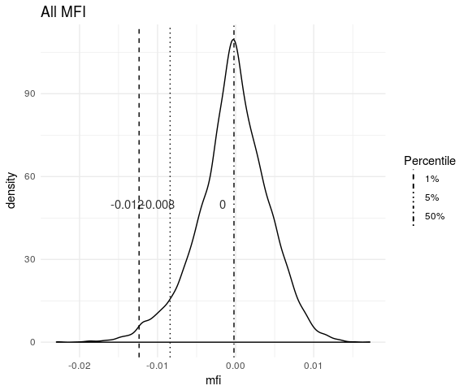

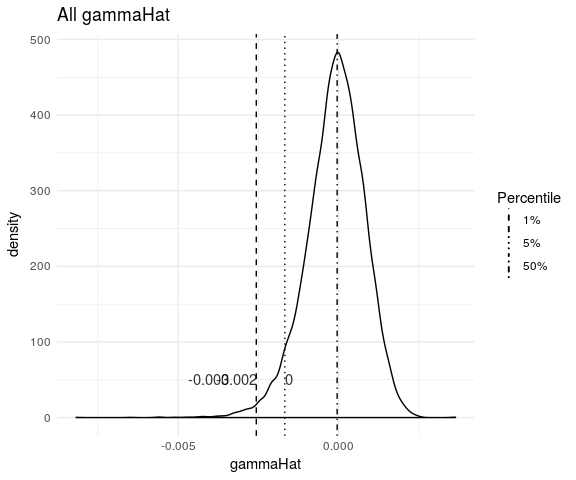

## MFI Plots

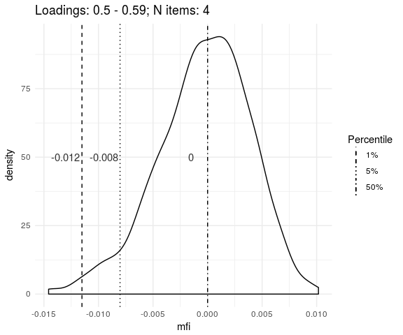

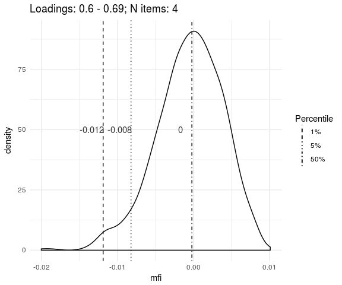

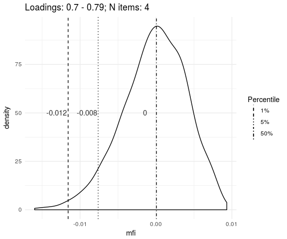

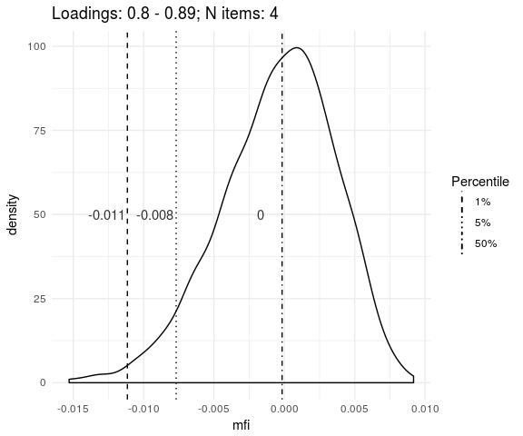

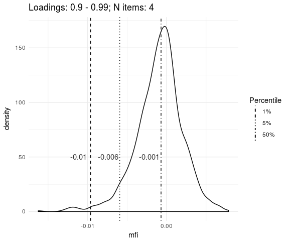

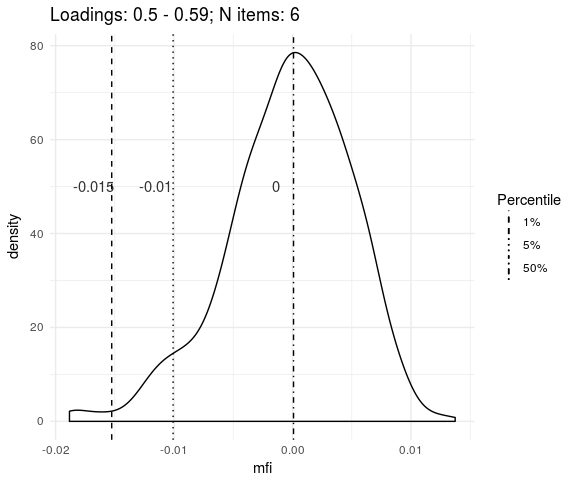

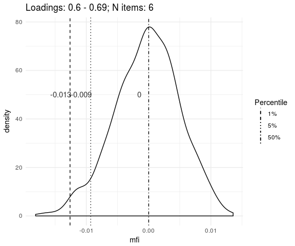

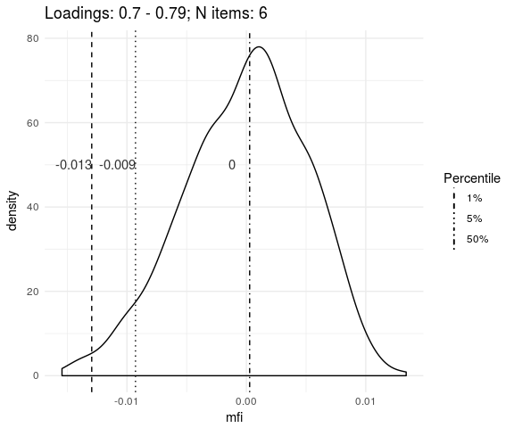

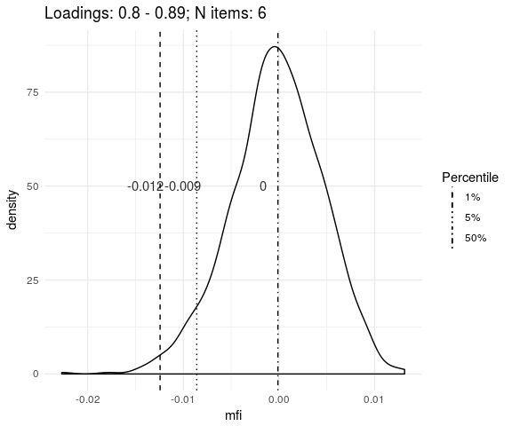

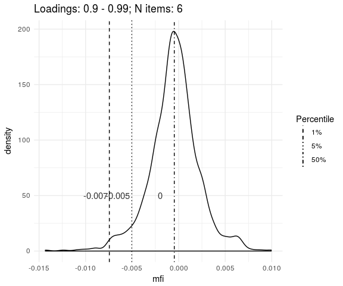

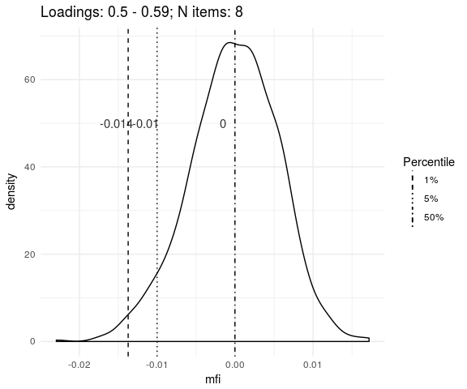

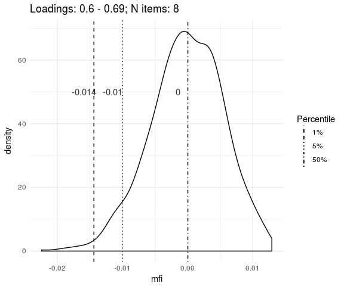

[3 more figures not shown]

## CFI Plots

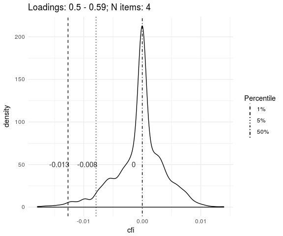

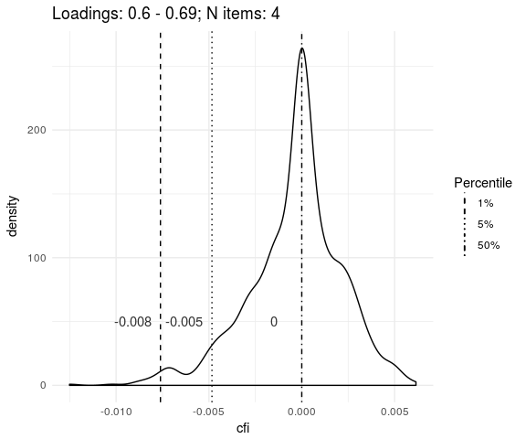

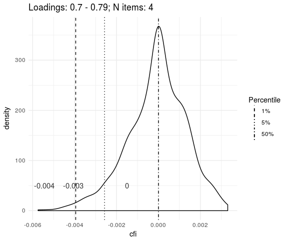

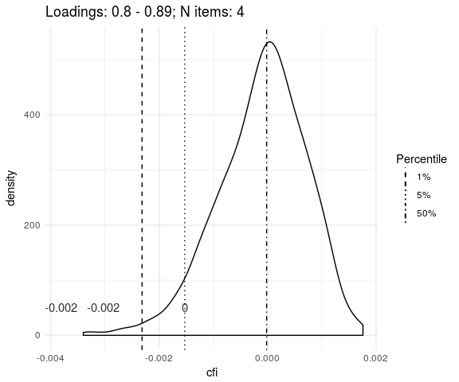

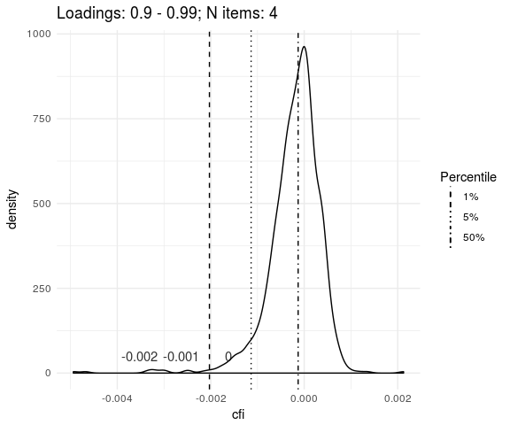

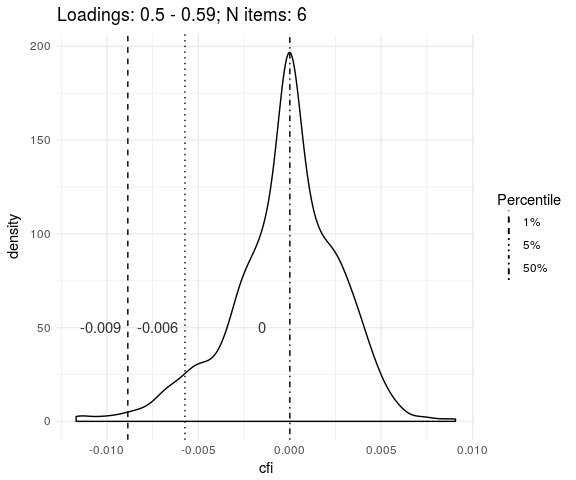

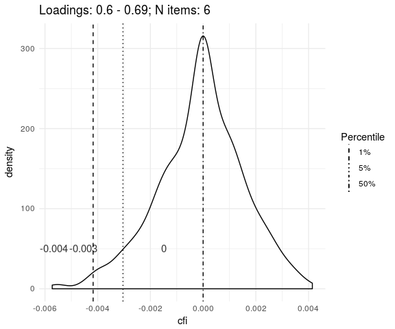

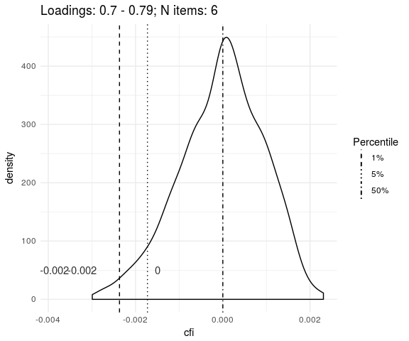

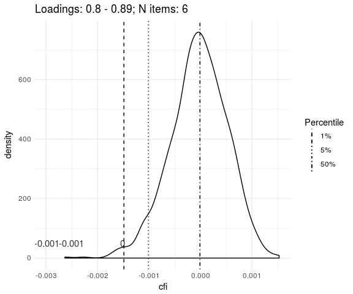

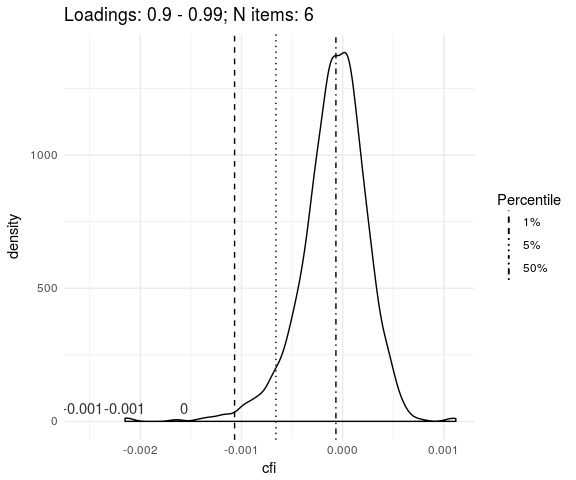

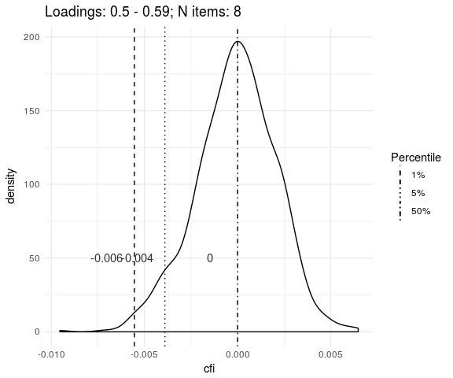

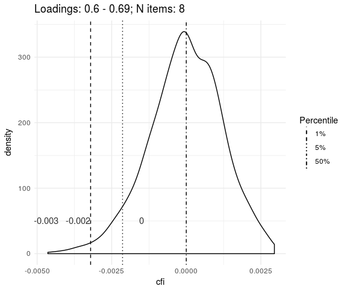

[3 more figures not shown]